# PracticalMachine-Learning

Robert Galla

4/5/2020

## Project Background

Using devices such as Jawbone Up, Nike FuelBand, and Fitbit it is now possible to collect a large amount of data about personal activity relatively inexpensively. These type of devices are part of the quantified self movement – a group of enthusiasts who take measurements about themselves regularly to improve their health, to find patterns in their behavior, or because they are tech geeks. One thing that people regularly do is quantify how much of a particular activity they do, but they rarely quantify how well they do it. In this project, the goal is to use data from accelerometers on the belt, forearm, arm, and dumbell of 6 participants. They were asked to perform barbell lifts correctly and incorrectly in 5 different ways. More information is available from the website here: http://groupware.les.inf.puc-rio.br/har (see the section on the Weight Lifting Exercise Dataset).

##Data Sources The data for this project come from this source: http://groupware.les.inf.puc-rio.br/har. The data is avalable through these URLS: Training Data: https://d396qusza40orc.cloudfront.net/predmachlearn/pml-training.csv

Test Data: https://d396qusza40orc.cloudfront.net/predmachlearn/pml-testing.csv

```r
library(caret)
```

```r
library(rpart)
library(rpart.plot)
library(rpart)
library(rpart.plot)
training_data_url <- "http://d396qusza40orc.cloudfront.net/predmachlearn/pml-training.csv"
testing_data_url  <- "http://d396qusza40orc.cloudfront.net/predmachlearn/pml-testing.csv"
training_data <- read.csv(url(training_data_url))
testing_data <- read.csv(url(testing_data_url))
```

## Data Prep

### Data Cleansing

Inspection of the data indiactes that columns 1 - 7 do not contain useful data for predictions.

```r
dim(training_data)
```

```
## [1] 19622   160
```

```r
training_data <- training_data[,8:160]
testing_data <- testing_data[,8:160]
```

This section removes all columns that have near zero variance.

```r
no_variance <- nearZeroVar(training_data)
training_data <- training_data[,-no_variance]
testing_data <- testing_data[,-no_variance]
dim(training_data)
```

```
## [1] 19622    94
```

This section removes columns where 95% of the rows values are NA

```r
NACols <-  colSums(is.na(training_data))/nrow(training_data) < 0.95
training_data <- training_data[,NACols]
testing_data <- testing_data[,NACols]
dim(training_data)
```

```
## [1] 19622    53
```

### Create Cross-validation dataset

```r
inTrain <- createDataPartition(training_data$classe, p=0.75)[[1]]
clean_training_data <- training_data[inTrain,]
crossvalidation_data <- training_data[-inTrain,]
dim(clean_training_data)
```

```
## [1] 14718    53
```

```r
dim(crossvalidation_data)
```

```
## [1] 4904   53
```

## Model Tournament

We will create three models, and choose the model with the highest accuracy for the final predictions

### Random Forest

Model 1 is using Random Forest

```r
set.seed(330)
rfModel <- train(classe ~., method='rf', data=clean_training_data, ntree=128)
rfPrediction <- predict(rfModel, crossvalidation_data)
confusionMatrix(crossvalidation_data$classe, rfPrediction)
```

```
## Confusion Matrix and Statistics
##
##           Reference
## Prediction    A    B    C    D    E
##          A 1395    0    0    0    0
##          B    4  941    4    0    0
##          C    0    4  847    4    0
##          D    0    0   12  791    1
##          E    0    0    1    2  898
##
## Overall Statistics
##
##                Accuracy : 0.9935
##                  95% CI : (0.9908, 0.9955)
##     No Information Rate : 0.2853
##     P-Value [Acc > NIR] : < 2.2e-16
##
##                   Kappa : 0.9917
##
##  Mcnemar's Test P-Value : NA
##
## Statistics by Class:
##
##                      Class: A Class: B Class: C Class: D Class: E
## Sensitivity            0.9971   0.9958   0.9803   0.9925   0.9989
## Specificity            1.0000   0.9980   0.9980   0.9968   0.9993
## Pos Pred Value         1.0000   0.9916   0.9906   0.9838   0.9967
## Neg Pred Value         0.9989   0.9990   0.9958   0.9985   0.9998
## Prevalence             0.2853   0.1927   0.1762   0.1625   0.1833
## Detection Rate         0.2845   0.1919   0.1727   0.1613   0.1831
## Detection Prevalence   0.2845   0.1935   0.1743   0.1639   0.1837
## Balanced Accuracy      0.9986   0.9969   0.9892   0.9947   0.9991
```

### Decision Tree

Model 2 is using Decision Tree

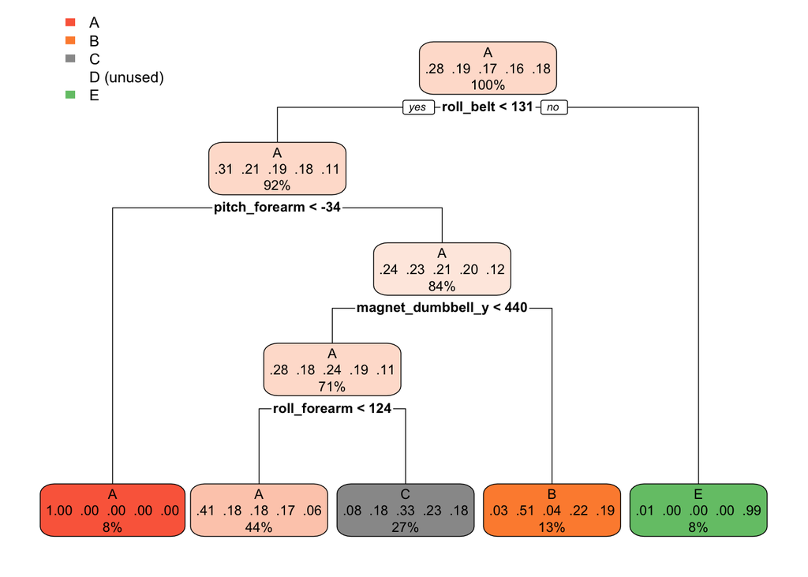

```r
DecisionTreeModel <- train(classe ~., method='rpart', data=clean_training_data)
DecisionTreePrediction <- predict(DecisionTreeModel, crossvalidation_data)
rpart.plot(DecisionTreeModel$finalModel)
```

```r
confusionMatrix(crossvalidation_data$classe, DecisionTreePrediction)
```

```
## Confusion Matrix and Statistics
##
##           Reference
## Prediction    A    B    C    D    E
##          A 1275   17  101    0    2
##          B  409  316  224    0    0
##          C  398   30  427    0    0
##          D  351  141  312    0    0
##          E  123  118  246    0  414
##
## Overall Statistics
##
##                Accuracy : 0.4959
##                  95% CI : (0.4818, 0.51)
##     No Information Rate : 0.5212
##     P-Value [Acc > NIR] : 0.9998
##
##                   Kappa : 0.3411
##
##  Mcnemar's Test P-Value : NA
##
## Statistics by Class:
##
##                      Class: A Class: B Class: C Class: D Class: E
## Sensitivity            0.4988  0.50804  0.32595       NA  0.99519
## Specificity            0.9489  0.85217  0.88091   0.8361  0.89149
## Pos Pred Value         0.9140  0.33298  0.49942       NA  0.45949
## Neg Pred Value         0.6349  0.92263  0.78192       NA  0.99950
## Prevalence             0.5212  0.12684  0.26713   0.0000  0.08483
## Detection Rate         0.2600  0.06444  0.08707   0.0000  0.08442
## Detection Prevalence   0.2845  0.19352  0.17435   0.1639  0.18373
## Balanced Accuracy      0.7239  0.68011  0.60343       NA  0.94334
```

### Gradient Boosting

Model 3 is using Gradient Boosting

```r
GBMmodel <- train(classe ~ ., data = clean_training_data, method = "gbm", verbose = FALSE)
GBMmodel$finalModel
```

```
## A gradient boosted model with multinomial loss function.
## 150 iterations were performed.
## There were 52 predictors of which 52 had non-zero influence.
```

```r
GBMPrediction <- predict(GBMmodel, crossvalidation_data)

GBMPrediction_conf <- confusionMatrix(GBMPrediction, crossvalidation_data$classe)
GBMPrediction_conf
```

```
## Confusion Matrix and Statistics
##
##           Reference
## Prediction    A    B    C    D    E
##          A 1373   34    0    1    1
##          B   15  889   22    2   10
##          C    2   23  823   33   10
##          D    5    2    8  761   21
##          E    0    1    2    7  859
##
## Overall Statistics
##
##                Accuracy : 0.9594
##                  95% CI : (0.9535, 0.9648)
##     No Information Rate : 0.2845
##     P-Value [Acc > NIR] : < 2.2e-16
##
##                   Kappa : 0.9487
##
##  Mcnemar's Test P-Value : 6.214e-07
##
## Statistics by Class:
##
##                      Class: A Class: B Class: C Class: D Class: E
## Sensitivity            0.9842   0.9368   0.9626   0.9465   0.9534
## Specificity            0.9897   0.9876   0.9832   0.9912   0.9975
## Pos Pred Value         0.9744   0.9478   0.9237   0.9548   0.9885
## Neg Pred Value         0.9937   0.9849   0.9920   0.9895   0.9896
## Prevalence             0.2845   0.1935   0.1743   0.1639   0.1837
## Detection Rate         0.2800   0.1813   0.1678   0.1552   0.1752
## Detection Prevalence   0.2873   0.1913   0.1817   0.1625   0.1772
## Balanced Accuracy      0.9870   0.9622   0.9729   0.9689   0.9754
```

## Prediction

Based on the accuracy of the three models, we choose the Random Forest model for predictions

```r
predict(rfModel, testing_data)
```

```
##  [1] B A B A A E D B A A B C B A E E A B B B
## Levels: A B C D E
```